# GC3 Workshop: Making a Reproducible Report

Winnie Wing-Yee Tse

2022-10-20

# Reproducibility

## Tip 1: Set things up at the beginning

It’s a good practice to load all libraries and import data that will be used at the top of the document.

```r
# load library
library(tidyverse)
# import data (beliefs about crying scale)
bacs <- read.csv("https://osf.io/6gsy8/download")
```

## Tip 2: Create a new data frame after making changes

I highly recommend saving the wrangled data frame into a new object and keep a copy of the original data frame. In any case the new data frame is messed up, we can always start again from the original data frame.

```r
# good practice
bacs_sub <- bacs %>%
  select(Gender, Age)
names(bacs_sub)
```

```
## [1] "Gender" "Age"
```

```r
# oh I forgot to include Ethnic
# let's start again from bacs which contains all variables
bacs_sub <- bacs %>%
  select(Gender, Age, Ethnic)
names(bacs_sub)
```

```
## [1] "Gender" "Age"    "Ethnic"
```

```r
# bad practice
bacs <- bacs %>%
  select(Gender, Age)
# now if we need Ethnic, all variables except Gender and Age are gone...
names(bacs)
# we need to reload the data to restore all variables
bacs <- read.csv("https://osf.io/6gsy8/download")
```

## Tip 3: Avoid hard coding

Let’s say we would like to report the mean of the sum scores of belief about crying.

```r
bacs_sum <- bacs %>%
  # calculate the sum score per individual
  mutate(big5_sum = rowSums(across(contains("BigV"))),
         bacs_sum = rowSums(across(contains("BACS"))),
         gender = recode(Gender, `1` = "Male", `2` = "Feamle"),
         age_bin = ifelse(Age >= 19, "Older than or at age 19",
                          "Younger than age 19"))
```

```r
(bacs_mean <- mean(bacs_sum$bacs_sum))
```

```
## [1] 44.72381
```

We should avoid hard coding by typing the number 44.72, but instead use “44.72” to print the result, mean of BACS = 44.72.

# Document format

## Tip 1: Set chunk options

To hide outputs, such as a long data frame, use the chunk option `results='hide'`.

```r
bacs
```

To hide codes, use the chunk option `echo=FALSE`.

```
## Warning: Removed 2 rows containing non-finite values (stat_smooth).
```

```
## Warning: Removed 2 rows containing missing values (geom_point).
```

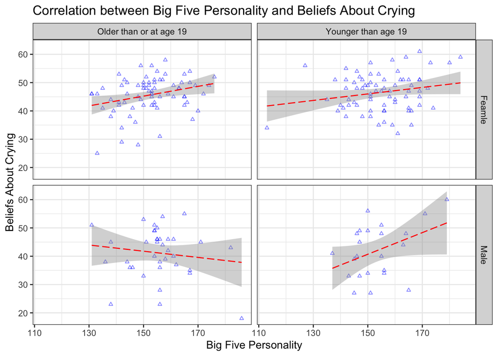

To suppress warnings and messages, use the chunk option `warnings=FALSE` and `message=FALSE`.

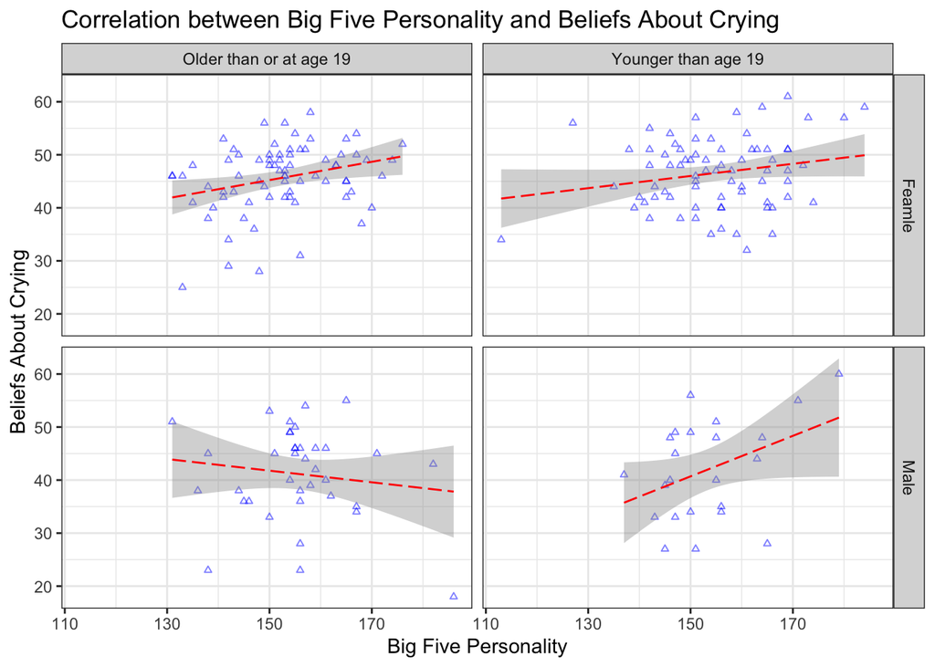

To show but not evaluate a code chunk, use the chunk option `eval=FALSE`.

```r
# will not be evaluated
bacs_test <- bacs
```

If a code chunk produces an error, R will stop knitting the entire document. It’s best to fix the bugs and resolve the errors. But sometimes if we want to force R to knit a document even if there an error, use the chunk option `error=TRUE`

```r
# as the above chunk wasn't evalauted,
# bacs_test does not exist
bacs_test
```

```
## Error in eval(expr, envir, enclos): object 'bacs_test' not found
```

## Tip 2: Table of content

The very top of the document contains the YAML metadata which determines the output format of the document.

```r
---
title: 'GC3 Workshop: Making a Reproducible Report'
author: "Winnie Wing-Yee Tse"
date: "`r Sys.Date()`"
output:
  html_document:
    toc: yes
    toc_depth: '2'
    df_print: paged
  pdf_document:
    toc: yes
    toc_depth: 2
---
```

`toc: TRUE` indicates that we want to include a table of content, and `toc_depth: 2` denotes that the level-1 and level-2 headers will be shown in the content page.

## Tip 3: Cheatsheet & Miscellaneous

Here is a [Rmarkdown cheatsheet](https://www.rstudio.com/wp-content/uploads/2015/02/rmarkdown-cheatsheet.pdf), which includes details about section headers, lists, etc.

Remember that one of my favorite functions is `ggsave()`? We can attach a previously exported image to a document, which sometimes saves us time from knitting the document when the running the analysis and making a plot are complex and computational intensive.

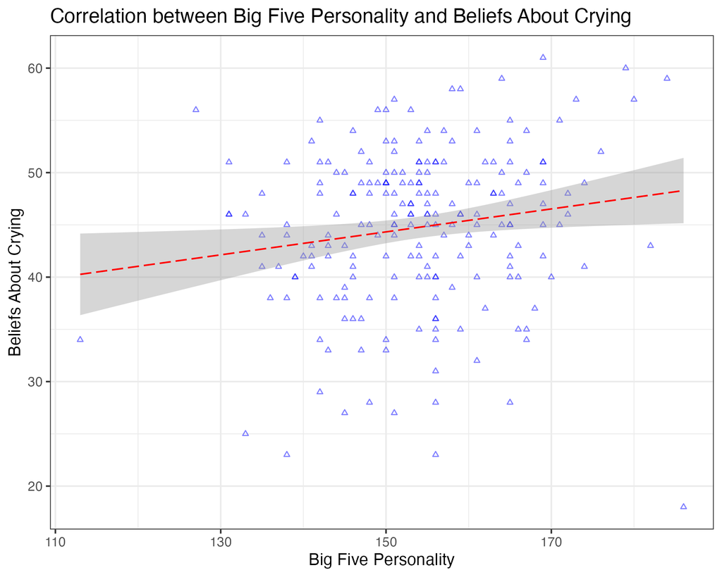

```r
knitr::include_graphics("big5_bacs.png")
```